# Chapter 08 Exercises

## Name goes here

### Date

```python
# Libraries you will need for this assignment.
# The code below will import them for your use.
# Please run this before continuing.
%matplotlib inline
import numpy as np
import pandas as pd
import matplotlib.pyplot as plt
```

## Q1) Inflation in China and India (FRED Question)

Using the data found [Here](https://github.com/dylanjm/econ_381_development/tree/master/data) import the inflation rates for `ch08_china_inflation.csv` and `ch08_india_inflation.csv`. Ensure to use the **raw url** for your Python code. Use your chapter 7 homework as a guide. I have already imported the data for china and converted it to arrays, so you will need to do the same for India and plot everything.

**(a)**: Using Python, create two time series plots showing the inflation rate for China and India for the years given in the data.

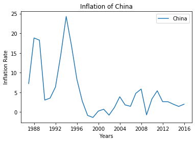

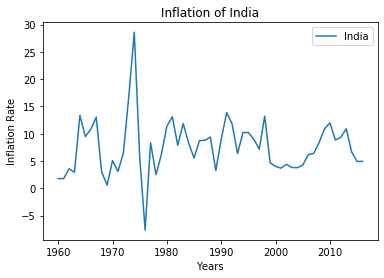

```python
# Import the data sets
china_url = "https://raw.githubusercontent.com/dylanjm/econ_381_development/master/data/ch08_china_inflation.csv"
china = pd.read_csv(china_url,header=0, names=['Date', 'China'])

india_url = "https://raw.githubusercontent.com/dylanjm/econ_381_development/master/data/ch08_india_inflation.csv"
india = pd.read_csv(india_url, header = 0, names = ['Date', 'India'])

#Convert the date variable to a datetime object
ChinaDate = np.array(china['Date'], dtype = np.datetime64)
ChinaInflation = np.array(china['China'])

IndiaDate = np.array(india['Date'], dtype = np.datetime64)
ChinaInflation = np.array(india['India'])

#plot
plt.plot(ChinaDate, china["China"], label ='China')
plt.xlabel('Years')
plt.ylabel('Inflation Rate')
plt.title('Inflation of China')
plt.legend()
plt.show()

plt.plot(IndiaDate, india["India"], label = 'India')
plt.xlabel('Years')
plt.ylabel('Inflation Rate')
plt.title('Inflation of India')
plt.legend()
plt.show()
```

**(b)**: What is the average inflation rate in each country for the most recent 5 years of data? What country had lower inflation?

```python
# Python Code for Part (b) Here:

#China
#2012: 100
#2013: 100 * 1.0262
#2014: 2013 * 1.02
#2015: 2014 * 1.0143
#2016: 2015 * 1.02

China_2012 = 100
China_inf = 100*1.0262*1.02*1.0143*1.02
China_avg = ((China_inf/China_2012)**(1/5) -1)*100
print('China inflation rate: {:.3f}%'.format(China_avg))

#India
#2012: 100
#2013: 100 * 1.1
#2014: 2013 * 1.066
#2015: 2014 * 1.049
#2016: 2015 * 1.049
India_2012 = 100
India_inf = 100*1.1*1.066*1.049*1.09
India_avg = ((India_inf/India_2012)**(1/5)-1)*100
print('India inflation rate: {:.3f}%'.format(India_avg))

print("China had lower inflation.")
```

```
China inflation rate: 1.606%
India inflation rate: 6.040%
China had lower inflation.
```

## Q2) Inflation and the quantity theory

Suppose velocity is contant, the growth rate of real GDP is 3% per year, and the growth rate of money is 5% per year. Calculate the long-run rate of inflation according to the quantity theory in each of the following cases:

**Calculate questions a-c on paper, then put the answers here**

**(a)**: What is the rate of inflation in the baseline case?

rate of inflation is 2% per year

**(b)**: Suppose the growth rate of money rises to 10% per year.

rate of inflation is 7% per year

**(c)**: Suppose the growth rate of money rises to 100% per year and the growth rate of GDP slows to -2\%.

rate of inflation is 102% per year

**Use python to calculate questions d-f**

**(d)**: Back to the baseline case, suppose real GDP growth rises to 5% per year.

```python
# Python Code Here:
gir = 5 - 5 + 0
print('inflation rate is', gir,'%')
```

```
inflation rate is 0 %
```

**(e)**: What if real GDP growth falls to 2% per year and the growth rate of money slows to 0\%?

```python
# Python Code Here:
gir1 = 0 + 0 - 2
print('inflation rate is', gir1,'%')
```

```
inflation rate is -2 %
```

**(f)**: Return to the baseline case and suppose the velocity of money rises at 1% per year. What happens to inflation in this case? Why might velocity change this fashion?

```python
# Python Code Here:
gir2 = 5 +1 - 3
print('inflation rate is', gir2, '%')
```

```
inflation rate is 3 %
```

The inflation rate grow up 1% compare to the baseline inflation because money liquidity became faster. Higher velocity works as more money in people hands.

## Q3) Inflation and interest rates in Italy (FRED Question)

Using the data found [Here](https://github.com/dylanjm/econ_381_development/tree/master/data) import the data for `ch08_italy_inflation.csv` and `ch08_italy_bond.csv`. Ensure to use the **raw url** for your Python code.

**(a)**: Using Python, create a **single** plot showing both the 10 year bond yields and inflation rate for Italy. Use the dates provided by the data.

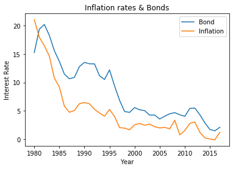

```python
# Python Code Here:

italy_url = "https://raw.githubusercontent.com/dylanjm/econ_381_development/master/data/ch08_italy_bond.csv"
italy_url2 = pd.read_csv("https://raw.githubusercontent.com/dylanjm/econ_381_development/master/data/ch08_italy_inflation.csv", header =0, names = ['Date','Inflation'])
italy = pd.read_csv(italy_url, header = 0, names=['Date', 'Bond'])
italy['Date'] = pd.to_datetime(italy['Date'])
italy['Year'] = italy['Date'].dt.year
ItalyBond = np.array(italy['Bond'])
plt.plot(italy['Year'], ItalyBond, label = 'Bond')
plt.plot(italy['Year'], italy_url2['Inflation'], label = 'Inflation')
plt.xlabel('Year')
plt.ylabel('Interest Rate')
plt.title('Inflation rates & Bonds')
plt.legend()
plt.show()
```

**(b)**: Why do these two series tend to move together over time?

If the inflation rises than the and bonds' interest which is fixed, who holds bonds losses money by inflation. If the inflation falls than the bonds' interest which is fixed, who holds bonds is better-off. To manage these issue, bonds interest rate should change as much as inflation changes. The bonds' interest rates are moving by the expectation of the economy of Italy. Bonds' interest rate is higher than the inflation rate because the country wants to attract the people from making money.

**(c)**: What economic concept corresponds to the difference between these two series?

Fisher equation. Same as Fisher equaiton (nominal - real = i), difference interest rate between the Bonds and inflation is the gain from the Bonds.